# Do not be tricked: GDP and ^STI

## Do not be tricked: GDP and ^STI

In this business times [article](http://www.businesstimes.com.sg/companies-markets/stock-market-a-poor-predictor-of-gdp-analysts) – **Stock market a poor predictor of GDP: analysts** – the author quotes the [motley fool](https://www.fool.sg/2015/06/18/singapores-economic-growth-is-slowing-heres-why-stock-market-investors-should-not-worry/), and mentions how GDP is not affected by the the stock market.

*Now, the good news. The impact of the limping stock market on the real economy is nada, according to market watchers. Analysts who have plotted Singapore's GDP growth rates over the years against the STI or the index's total returns have discovered that there is no discernible link between them.*

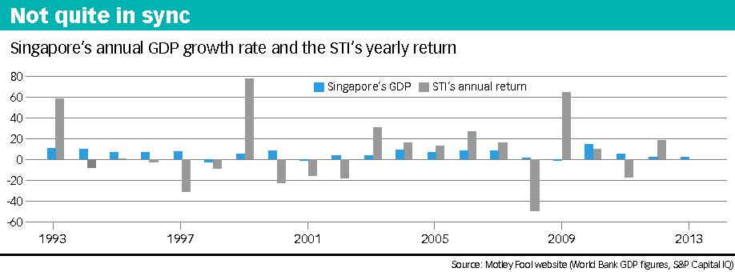

Is this complete BS?

### Singapore's GDP

We extract Singapore's GDP values from the world bank using the `WDI` package.

```r
gdp = WDI("SG", "NY.GDP.MKTP.KD.ZG", start=1993, end=2014)
gdp = setNames(gdp[,3:4], c("gdp", "year"))
gdp %<>% arrange(year)
```

### Annual Returns for ^STI

```r
stiDF = getSymbols("^STI", from = "1993-01-01", to = "2014-12-31", auto.assign = FALSE)
rSTI = annualReturn(stiDF)
rSTI %<>% as.data.frame
```

First we plot the GDP growth rate against STI annual return rates, year by year, in the same year. Correlation between the two seems to be all over the place.

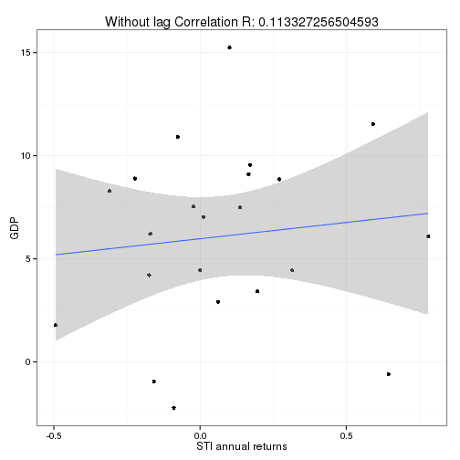

Next, we introduce some lag – to be precise, 1 year; where the GDP is lagging – and we see how well the correlation is (R value: 0.7862812)

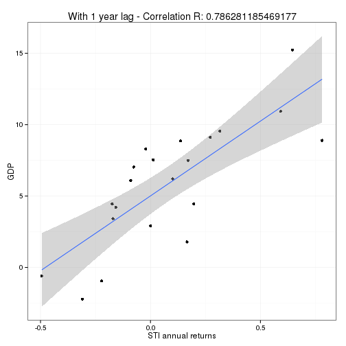

## Conclusion

Watch out folks dont believe any techie who is able to write a blog, and be frugal with your trust! Not even businesstimes!